# Diet ~ landscape revisited

```r
# Import conflict settings.
source('../src/conflicted.R')

#Load some libraries.
library(tidyverse)
library(vegan)
library(raster)
library(sf)
library(landscapemetrics)
library(broom)
library(knitr)
library(kableExtra)
library(GGally)
library(extrafont)
```

Start by defining the four nested scales. In the last version I used 32902.97 ha for the maximum area, which is completely incorrect and I have no idea where it came from. I re-did the calculation and came out with a radius of about 7047 m (mean maximum distance travelled by males during the breeding season). This works out to an area of 15602.21, which I can round to 15600 ha.

```r
# Area is in hectares.
landscape <- data.frame(
  size=c('PFA', 'breeding area', 'home range', 'maximum range'),
  area=c(60, 200, 3800, 15600)
)

# Convert area in hectares to radii in meters.
landscape <- landscape %>% mutate(radius=sqrt(area*10000/pi))

landscape
```

| size | area | radius |
| --- | --- | --- |
| PFA | 60 | 437.0194 |
| breeding area | 200 | 797.8846 |
| home range | 3800 | 3477.8982 |
| maximum range | 15600 | 7046.7256 |

Then load in diet data and calculate the standard diet variables: diet diversity and proportion squirrel.

```r
# Bring in diet data.
source('../src/prey_attributes_revised.R')
```

[output not shown]

```r
# Take only items identified to genus and twist to a wide format.
diet.wide <- diet.items %>% filter(binomial != 'Unidentified item' & method == 'camera') %>%
  group_by(nest, genus, species) %>%
  mutate(count=n()) %>% ungroup() %>%
  dplyr::select(nest, binomial, count) %>%
  distinct() %>%
  pivot_wider(names_from=binomial, values_from=count,
              values_fill=list(count = 0))

# Calculate diet diversity.
diet.diversity <- plyr::ddply(diet.wide, ~nest, function(x) {
           data.frame(diet.diversity=diversity(x[-1], index='simpson'))
   })

# Proportion of diet made up of squirrel, by biomass.
proportion.squirrel <- diet.items %>%
  filter(method == 'camera') %>%
  mutate(mass=as.numeric(mass)) %>%
  group_by(nest) %>%
  mutate(total=sum(mass)) %>%
  filter(genus == 'Tamiasciurus') %>%
  mutate(amount.sq=sum(mass), proportion.squirrel=amount.sq/total) %>%
  select(site, nest, proportion.squirrel) %>% distinct()

# Join them together.
diet.variables <- full_join(diet.diversity, proportion.squirrel, by=c('nest'))

# Look at them.
diet.variables
```

| nest | diet.diversity | site | proportion.squirrel |
| --- | --- | --- | --- |
| MTC2019 | 0.4813841 | MTC | 0.7172089 |
| MTF2019 | 0.4805010 | MTF | 0.7167476 |
| RLK2019 | 0.0768000 | RLK | 0.7755876 |
| TCR2019 | 0.3495111 | TCR | 0.8112324 |
| TMC2019 | 0.5840995 | TMC | 0.4872569 |
| UTZ2019 | 0.6620643 | UTZ | 0.7271142 |

Now bring in the centroids for all of these sites. The centroids are just calculated from all the known nests for a given site and provide a stable, central “capital” for the territory. Which is BS but whatever.

```r
# Bring in centroid data.
centroids <- read_csv('../data/interim/zone_centroid_sites.csv')

# Join to occupancy data. Not all sites have occupancy data, so we'll keep just the ones that do.
sites <- left_join(diet.variables, centroids, by=c('site')) %>%
  rename(xcoord=MEAN_X, ycoord=MEAN_Y) %>%
  drop_na()

# Make it a spatial object for later.
sites.sf <- sites %>%
  st_as_sf(coords=c('xcoord', 'ycoord')) %>%
  st_set_crs('+proj=utm +zone=10 +datum=WGS84 +units=m +no_defs')

# Also make a list of site names for later.
site.names <- sites$site
```

Next step is to bring in the landscape rasters and calculate all the metrics.

```r
# Load all the rasters.
source('../src/load_rasters.R')

# Calculate metrics for each site.
source('../src/calc_land_metrics.R')

# Join the data together.
data <- full_join(sites, bec.landscape.metrics, by=c('site' = 'nest')) %>%
  full_join(suitable.landscape.metrics, by=c('site' = 'nest', 'radius')) %>%
  full_join(landcover.landscape.metrics, by=c('site' = 'nest', 'radius', 'size')) %>%
  full_join(hsi.landscape.metrics, by=c('site' = 'nest', 'radius', 'size')) %>%
  full_join(gap.landscape.metrics, by=c('site' = 'nest', 'radius', 'size')) %>%
  full_join(canopy.landscape.metrics, by=c('site' = 'nest', 'radius', 'size'))
```

Looks like Stewart Island (SIS) has less than 90% coverage for BEC, and for the HSI. So I’ll remove it.

```r
data <- data %>% filter(site != 'SIS')
```

There’s also an annoying NaN that will break everything, so I’ll change that.

```r
data <- data %>% mutate(cover.evenness=case_when(
  cover.evenness == 'NaN' ~ NA_real_,
  TRUE ~ cover.evenness
))
```

```r
# Bring in previously calculated data.
# data <- readRDS('../data/interim/occupancy_landscape_metrics.rds')
```

Note that a few of these sites have less than 90% of their area with data coverage for some things (I think about four sites, as some scale or another) and I haven’t tracked them down and removed them yet.

```r
# Save for now, since it takes a while to calculate.
# saveRDS(data, '../data/interim/occupancy_landscape_metrics.rds')
```

Now… finally make the models?

Here’s what one looks like, just to show the simple code:

```r
lm(diet.diversity ~ proportion.suitable, data=data)
```

```
Call:
lm(formula = diet.diversity ~ proportion.suitable, data = data)

Coefficients:
        (Intercept)  proportion.suitable
           0.298299             0.002056
```

And here’s the whole slew of them:

```r
# Proportion suitable.
diet.diversity.by.bec.diversity <- data %>%
  drop_na(diet.diversity) %>%
  split(.$size) %>%
  map(~lm(diet.diversity ~ bec.diversity, data=.x)) %>%
  map(tidy) %>%
  bind_rows(.id='size') %>%
  mutate(variable='forest type diversity')

# Proportion older forest.
diet.diversity.by.proportion.cover.mature <- data %>%
  drop_na(diet.diversity) %>%
  filter(nest != 'TCR2019') %>%
  split(.$size) %>%
  map(~lm(diet.diversity ~ proportion.cover.mature, data=.x)) %>%
  map(tidy) %>%
  bind_rows(.id='size') %>%
  mutate(variable='proportion older forest')

# Landcover edge density.
diet.diversity.by.cover.edge.density <- data %>%
  drop_na(diet.diversity) %>%
  filter(nest != 'TCR2019') %>%
  split(.$size) %>%
  map(~lm(diet.diversity ~ cover.edge.density, data=.x)) %>%
  map(tidy) %>%
  bind_rows(.id='size') %>%
  mutate(variable='landcover edge density')

# Landcover contagion.
diet.diversity.by.cover.contagion <- data %>%
  drop_na(diet.diversity) %>%
  filter(nest != 'TCR2019') %>%
  split(.$size) %>%
  map(~lm(diet.diversity ~ cover.contagion, data=.x)) %>%
  map(tidy) %>%
  bind_rows(.id='size') %>%
  mutate(variable='landcover contagion')

# Landcover diversity.
diet.diversity.by.cover.diversity <- data %>%
  drop_na(diet.diversity) %>%
  filter(nest != 'TCR2019') %>%
  split(.$size) %>%
  map(~lm(diet.diversity ~ cover.diversity, data=.x)) %>%
  map(tidy) %>%
  bind_rows(.id='size') %>%
  mutate(variable='landcover diversity')

# Landcover richness.
diet.diversity.by.cover.richness <- data %>%
  drop_na(diet.diversity) %>%
  filter(nest != 'TCR2019') %>%
  split(.$size) %>%
  map(~lm(diet.diversity ~ cover.richness, data=.x)) %>%
  map(tidy) %>%
  bind_rows(.id='size') %>%
  mutate(variable='landcover richness')

# Landcover evenness.
diet.diversity.by.cover.evenness <- data %>%
  drop_na(diet.diversity) %>%
  filter(nest != 'TCR2019') %>%
  split(.$size) %>%
  map(~lm(diet.diversity ~ cover.evenness, data=.x)) %>%
  map(tidy) %>%
  bind_rows(.id='size') %>%
  mutate(variable='landcover evenness')

# Gap edge density.
diet.diversity.by.gap.edge.density <- data %>%
  drop_na(diet.diversity) %>%
  filter(nest != 'TCR2019') %>%
  split(.$size) %>%
  map(~lm(diet.diversity ~ gap.edge.density, data=.x)) %>%
  map(tidy) %>%
  bind_rows(.id='size') %>%
  mutate(variable='gap edge density')

# Canopy cover.
diet.diversity.by.canopy.cover <- data %>%
  drop_na(diet.diversity) %>%
  filter(nest != 'TCR2019') %>%
  split(.$size) %>%
  map(~lm(diet.diversity ~ canopy.high, data=.x)) %>%
  map(tidy) %>%
  bind_rows(.id='size') %>%
  mutate(variable='high canopy cover')

# HSI edge density.
diet.diversity.by.hsi.edge.density <- data %>%
  drop_na(diet.diversity) %>%
  filter(nest != 'TCR2019') %>%
  split(.$size) %>%
  map(~lm(diet.diversity ~ hsi.edge.density, data=.x)) %>%
  map(tidy) %>%
  bind_rows(.id='size') %>%
  mutate(variable='hsi edge density')

# HSI contagion.
diet.diversity.by.hsi.contagion <- data %>%
  drop_na(diet.diversity) %>%
  filter(nest != 'TCR2019') %>%
  split(.$size) %>%
  map(~lm(diet.diversity ~ hsi.contagion, data=.x)) %>%
  map(tidy) %>%
  bind_rows(.id='size') %>%
  mutate(variable='hsi contagion')

# Proportion suitable.
diet.diversity.by.proportion.suitable <- data %>%
  drop_na(diet.diversity) %>%
  filter(nest != 'TCR2019') %>%
  split(.$size) %>%
  map(~lm(diet.diversity ~ proportion.suitable, data=.x)) %>%
  map(tidy) %>%
  bind_rows(.id='size') %>%
  mutate(variable='proportion suitable')

# Suitable habitat edge density.
diet.diversity.by.suitable.edge.density <- data %>%
  drop_na(diet.diversity) %>%
  filter(nest != 'TCR2019') %>%
  split(.$size) %>%
  map(~lm(diet.diversity ~ suitable.edge.density, data=.x)) %>%
  map(tidy) %>%
  bind_rows(.id='size') %>%
  mutate(variable='suitable habitat edge density')

# Bind it all together.
diet.diversity.landscape.statistics <- bind_rows(diet.diversity.by.bec.diversity,
          diet.diversity.by.proportion.cover.mature,
          diet.diversity.by.cover.edge.density,
          diet.diversity.by.cover.contagion,
          diet.diversity.by.cover.diversity,
          diet.diversity.by.cover.evenness,
          diet.diversity.by.cover.richness,
          diet.diversity.by.gap.edge.density,
          diet.diversity.by.canopy.cover,
          diet.diversity.by.hsi.edge.density,
          diet.diversity.by.hsi.contagion,
          diet.diversity.by.proportion.suitable,
          diet.diversity.by.suitable.edge.density)
```

```r
# saveRDS(occupancy.landscape.statistics, '../data/interim/occupancy_landscape_stats.rds')
```

Stick it all in a beautiful table of p-values.

```r
diet.diversity.landscape.statistics <- diet.diversity.landscape.statistics %>%
  mutate(sig=round(p.value, digits=2)) %>%
  mutate(sig=case_when(
  p.value < 0.05 ~ paste(as.character(sig), '*'),
  TRUE ~  paste(as.character(sig))
))

diet.diversity.landscape.statistics %>%
  filter(term != '(Intercept)') %>%
  select(size, sig, variable) %>%
  pivot_wider(names_from=size, values_from=sig) %>%
  select(variable, PFA, everything()) %>%
  kable() %>% kable_styling(bootstrap_options=c('striped'))
```

| variable | PFA | breeding area | home range | maximum range |
| --- | --- | --- | --- | --- |
| forest type diversity | 0.25 | 0.28 | 0.28 | 0.11 |
| proportion older forest | 0.96 | 0.98 | 0.37 | 0.17 |
| landcover edge density | 0.89 | 0.93 | 0.76 | 0.76 |
| landcover contagion | 0.39 | 1 | 0.51 | 0.44 |
| landcover diversity | 0.78 | 0.92 | 0.51 | 0.31 |
| landcover evenness | 0.34 | 0.97 | 0.49 | 0.34 |
| landcover richness | 0.79 | 0.49 | 0.84 | 0.88 |
| gap edge density | 0.89 | 0.3 | 0.42 | 0.24 |
| high canopy cover | 0.93 | 0.93 | 0.33 | 0.03 * |
| hsi edge density | 0.99 | 0.96 | 0.9 | 0.78 |
| hsi contagion | 0.86 | 0.5 | 0.42 | 0.69 |
| proportion suitable | 0.82 | 0.5 | 0.22 | 0.37 |
| suitable habitat edge density | 0.85 | 0.6 | 0.7 | 0.49 |

Only one thing is significant, proportion of landscape in high canopy cover.

Now we do it again with proportion squirrel.

```r
# Proportion suitable.
proportion.squirrel.by.bec.diversity <- data %>%
  drop_na(proportion.squirrel) %>%
  split(.$size) %>%
  map(~lm(proportion.squirrel ~ bec.diversity, data=.x)) %>%
  map(tidy) %>%
  bind_rows(.id='size') %>%
  mutate(variable='forest type diversity')

# Proportion older forest.
proportion.squirrel.by.proportion.cover.mature <- data %>%
  drop_na(proportion.squirrel) %>%
  filter(nest != 'TCR2019') %>%
  split(.$size) %>%
  map(~lm(proportion.squirrel ~ proportion.cover.mature, data=.x)) %>%
  map(tidy) %>%
  bind_rows(.id='size') %>%
  mutate(variable='proportion older forest')

# Landcover edge density.
proportion.squirrel.by.cover.edge.density <- data %>%
  drop_na(proportion.squirrel) %>%
  filter(nest != 'TCR2019') %>%
  split(.$size) %>%
  map(~lm(proportion.squirrel ~ cover.edge.density, data=.x)) %>%
  map(tidy) %>%
  bind_rows(.id='size') %>%
  mutate(variable='landcover edge density')

# Landcover contagion.
proportion.squirrel.by.cover.contagion <- data %>%
  drop_na(proportion.squirrel) %>%
  filter(nest != 'TCR2019') %>%
  split(.$size) %>%
  map(~lm(proportion.squirrel ~ cover.contagion, data=.x)) %>%
  map(tidy) %>%
  bind_rows(.id='size') %>%
  mutate(variable='landcover contagion')

# Landcover diversity.
proportion.squirrel.by.cover.diversity <- data %>%
  drop_na(proportion.squirrel) %>%
  filter(nest != 'TCR2019') %>%
  split(.$size) %>%
  map(~lm(proportion.squirrel ~ cover.diversity, data=.x)) %>%
  map(tidy) %>%
  bind_rows(.id='size') %>%
  mutate(variable='landcover diversity')

# Landcover richness.
proportion.squirrel.by.cover.richness <- data %>%
  drop_na(proportion.squirrel) %>%
  filter(nest != 'TCR2019') %>%
  split(.$size) %>%
  map(~lm(proportion.squirrel ~ cover.richness, data=.x)) %>%
  map(tidy) %>%
  bind_rows(.id='size') %>%
  mutate(variable='landcover richness')

# Landcover evenness.
proportion.squirrel.by.cover.evenness <- data %>%
  drop_na(proportion.squirrel) %>%
  filter(nest != 'TCR2019') %>%
  split(.$size) %>%
  map(~lm(proportion.squirrel ~ cover.evenness, data=.x)) %>%
  map(tidy) %>%
  bind_rows(.id='size') %>%
  mutate(variable='landcover evenness')

# Gap edge density.
proportion.squirrel.by.gap.edge.density <- data %>%
  drop_na(proportion.squirrel) %>%
  filter(nest != 'TCR2019') %>%
  split(.$size) %>%
  map(~lm(proportion.squirrel ~ gap.edge.density, data=.x)) %>%
  map(tidy) %>%
  bind_rows(.id='size') %>%
  mutate(variable='gap edge density')

# Canopy cover.
proportion.squirrel.by.canopy.cover <- data %>%
  drop_na(proportion.squirrel) %>%
  filter(nest != 'TCR2019') %>%
  split(.$size) %>%
  map(~lm(proportion.squirrel ~ canopy.high, data=.x)) %>%
  map(tidy) %>%
  bind_rows(.id='size') %>%
  mutate(variable='high canopy cover')

# HSI edge density.
proportion.squirrel.by.hsi.edge.density <- data %>%
  drop_na(proportion.squirrel) %>%
  filter(nest != 'TCR2019') %>%
  split(.$size) %>%
  map(~lm(proportion.squirrel ~ hsi.edge.density, data=.x)) %>%
  map(tidy) %>%
  bind_rows(.id='size') %>%
  mutate(variable='hsi edge density')

# HSI contagion.
proportion.squirrel.by.hsi.contagion <- data %>%
  drop_na(proportion.squirrel) %>%
  filter(nest != 'TCR2019') %>%
  split(.$size) %>%
  map(~lm(proportion.squirrel ~ hsi.contagion, data=.x)) %>%
  map(tidy) %>%
  bind_rows(.id='size') %>%
  mutate(variable='hsi contagion')

# Proportion suitable.
proportion.squirrel.by.proportion.suitable <- data %>%
  drop_na(proportion.squirrel) %>%
  filter(nest != 'TCR2019') %>%
  split(.$size) %>%
  map(~lm(proportion.squirrel ~ proportion.suitable, data=.x)) %>%
  map(tidy) %>%
  bind_rows(.id='size') %>%
  mutate(variable='proportion suitable')

# Suitable habitat edge density.
proportion.squirrel.by.suitable.edge.density <- data %>%
  drop_na(proportion.squirrel) %>%
  filter(nest != 'TCR2019') %>%
  split(.$size) %>%
  map(~lm(proportion.squirrel ~ suitable.edge.density, data=.x)) %>%
  map(tidy) %>%
  bind_rows(.id='size') %>%
  mutate(variable='suitable habitat edge density')

# Bind it all together.
proportion.squirrel.landscape.statistics <- bind_rows(proportion.squirrel.by.bec.diversity,
          proportion.squirrel.by.proportion.cover.mature,
          proportion.squirrel.by.cover.edge.density,
          proportion.squirrel.by.cover.contagion,
          proportion.squirrel.by.cover.diversity,
          proportion.squirrel.by.cover.evenness,
          proportion.squirrel.by.cover.richness,
          proportion.squirrel.by.gap.edge.density,
          proportion.squirrel.by.canopy.cover,
          proportion.squirrel.by.hsi.edge.density,
          proportion.squirrel.by.hsi.contagion,
          proportion.squirrel.by.proportion.suitable,
          proportion.squirrel.by.suitable.edge.density)
```

Stick it all in a beautiful table of p-values.

```r
proportion.squirrel.landscape.statistics <- proportion.squirrel.landscape.statistics %>%
  mutate(sig=round(p.value, digits=2)) %>%
  mutate(sig=case_when(
  p.value < 0.05 ~ paste(as.character(sig), '*'),
  TRUE ~  paste(as.character(sig))
))

proportion.squirrel.landscape.statistics %>%
  filter(term != '(Intercept)') %>%
  select(size, sig, variable) %>%
  pivot_wider(names_from=size, values_from=sig) %>%
  select(variable, PFA, everything()) %>%
  kable() %>% kable_styling(bootstrap_options=c('striped'))
```

| variable | PFA | breeding area | home range | maximum range |
| --- | --- | --- | --- | --- |
| forest type diversity | 0.83 | 0.83 | 0.62 | 0.5 |
| proportion older forest | 0.42 | 0.41 | 0.06 | 0.1 |
| landcover edge density | 0.22 | 0.26 | 0.51 | 0.66 |
| landcover contagion | 0.79 | 0.18 | 0.03 * | 0.17 |
| landcover diversity | 0.21 | 0.22 | 0.01 * | 0.11 |
| landcover evenness | 0.71 | 0.21 | 0.01 * | 0.12 |
| landcover richness | 0.17 | 0.34 | 0.14 | 0.67 |
| gap edge density | 0.7 | 0.97 | 0.67 | 0.56 |
| high canopy cover | 0.8 | 0.8 | 0.34 | 0.3 |
| hsi edge density | 0.64 | 0.52 | 0.64 | 0.43 |
| hsi contagion | 0.64 | 0.18 | 0.71 | 0.84 |
| proportion suitable | 0.62 | 0.37 | 0.06 | 0.52 |
| suitable habitat edge density | 0.65 | 0.46 | 0.23 | 0.16 |

```r
proportion.squirrel.landscape.statistics %>%
  filter(term != '(Intercept)' & p.value < 0.05) %>%
  select(size, estimate, variable) %>%
  pivot_wider(names_from=size, values_from=estimate) %>%
  #select(variable, PFA, `breeding area`, everything()) %>%
  kable() %>% kable_styling(bootstrap_options=c('striped'))
```

| variable | home range |
| --- | --- |
| landcover contagion | -0.0122085 |
| landcover diversity | 0.6748902 |
| landcover evenness | 0.6001520 |

This is a depressingly different result than I got earlier, possibly due to the fact that I re-made my rasters at a consistent (but larger) scale.

These are so highly correlated there hardly seems to be a point in making a matrix, but…

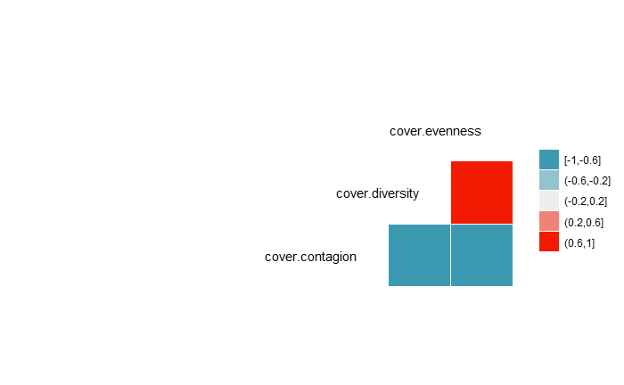

```r
data %>% filter(size == 'maximum range') %>%
  select(cover.contagion, cover.diversity, cover.evenness) %>%
  ggcorr(method=c('pairwise', 'pearson'), nbreaks=5, hjust=1, layout.exp=5)
```

And finally, do any of them make pretty graphs.

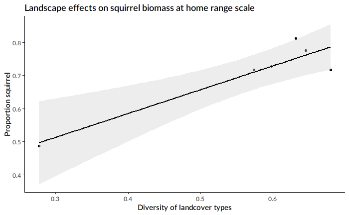

```r
data %>% filter(size == 'home range') %>%
  ggplot(aes(x=cover.diversity, y=proportion.squirrel)) +
  geom_point() +
  geom_smooth(formula='y ~ x', method='lm', se=TRUE, col='black', fill='lightgrey') +
  labs(title='Landscape effects on squirrel biomass at home range scale') +
  ylab('Proportion squirrel') +
  xlab('Diversity of landcover types') +
  theme_classic() +
  theme(text=element_text(family="Lato Semibold"))
```

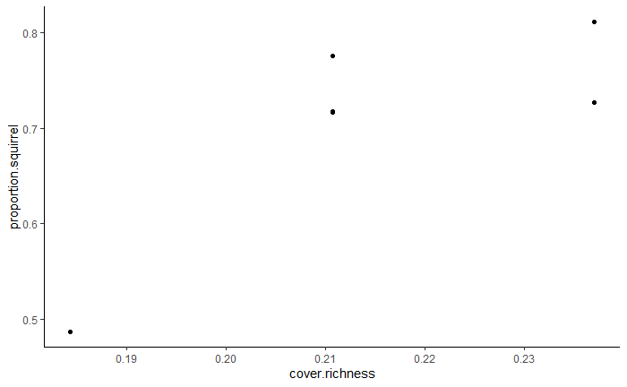

```r
data %>% filter(size == 'home range') %>%
  ggplot(aes(x=cover.richness, y=proportion.squirrel)) +
  geom_point() +
  theme_classic()
```

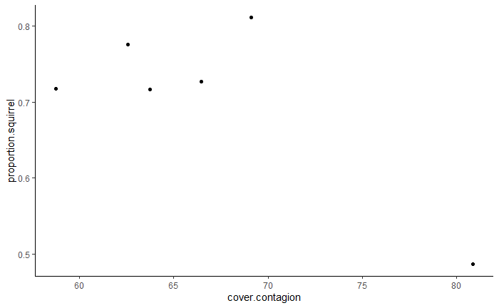

```r
data %>% filter(size == 'home range') %>%
  ggplot(aes(x=cover.contagion, y=proportion.squirrel)) +
  geom_point() +
  theme_classic()
```